# PS270 Final Project

My final project

Meghan McKenna

## Project thoughts

I am interested in exploring data related to swing state election trends, and how they change over time or related to voter’s most important issues. Additionally, I am curious how voter’s choices change after marriage or after having children. How do these monumental life choices impact their political ideology or how often they vote, if at all.

## Data Set

```r
library(tidyverse)
library(readr)
judges <- read_csv("data/agjudgeyear_full.csv")
```

```r
head(judges)
```

```
# A tibble: 6 × 15
   ...1    nid first.name last.name eval.year court   pap gender asian
  <dbl>  <dbl> <chr>      <chr>         <dbl> <chr> <dbl>  <dbl> <dbl>
1     1 4.26e6 A.         Quattleb…      2021 U.S.…     1      1     0
2     2 4.26e6 A.         Quattleb…      2024 U.S.…     1      1     0
3     3 1.39e6 Abner      Mikva          1990 U.S.…     0      1     0
4     4 1.39e6 Abner      Mikva          1994 U.S.…     0      1     0
5     5 1.39e6 Adalberto  Jordan         2015 U.S.…     0      1     0
6     6 1.39e6 Adalberto  Jordan         2017 U.S.…     0      1     0
# ℹ 6 more variables: black <dbl>, hispanic <dbl>, white <dbl>,
#   judjis_score <dbl>, ci_l <dbl>, ci_u <dbl>
```

# Research Question

My research question is have US Court of Appeals judges become more politically polarized over time? My hypothesis is that judges’ ideological scores have, on average, become more polarized over time, given political parties have trended in that direction. Since presidents appoint circuit court judges, who then must be confirmed by the Senate, they will likely choose a candidate in line with their own political ideology. Therefore, political extremism will follow through in presidents’ actions. My explanatory variable would be time, measured in years, and it would vary by whether they were appointed by a Republican or Democrat. This is useful to see which political party appoints more ideologically extreme judges. The outcome variable of interest is political ideology, measured in the Jurist-Derived Judicial Ideology Score. An observed pattern in the data that would provide support would be the absolute values of the JuDJIS scores increasing as the year increases, a positive relationship. An observed pater that would disprove my hypothesis would be the average JuDJIS scores not changing over time, or the absolute values decreasing with time.

## Data Visualization

```r
judges
```

```
# A tibble: 2,268 × 15
    ...1     nid first.name last.name   eval.year court     pap gender
   <dbl>   <dbl> <chr>      <chr>           <dbl> <chr>   <dbl>  <dbl>
 1     1 4263096 A.         Quattlebaum      2021 U.S. C…     1      1
 2     2 4263096 A.         Quattlebaum      2024 U.S. C…     1      1
 3     3 1385106 Abner      Mikva            1990 U.S. C…     0      1
 4     4 1385106 Abner      Mikva            1994 U.S. C…     0      1
 5     5 1390991 Adalberto  Jordan           2015 U.S. C…     0      1
 6     6 1390991 Adalberto  Jordan           2017 U.S. C…     0      1
 7     7 1390991 Adalberto  Jordan           2020 U.S. C…     0      1
 8     8 1390991 Adalberto  Jordan           2024 U.S. C…     0      1
 9     9 1384036 Alan       Lourie           1995 U.S. C…     1      1
10    10 1384036 Alan       Lourie           1999 U.S. C…     1      1
# ℹ 2,258 more rows
# ℹ 7 more variables: asian <dbl>, black <dbl>, hispanic <dbl>,
#   white <dbl>, judjis_score <dbl>, ci_l <dbl>, ci_u <dbl>
```

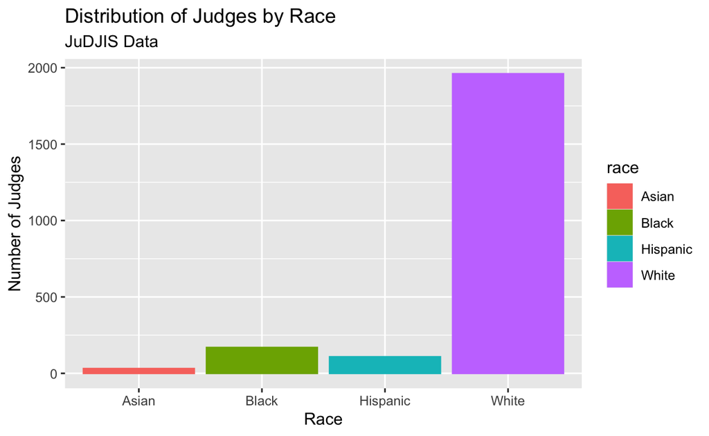

```r
library(ggplot2)
library(tidyverse)

judges <- judges |>
  mutate(
    race = case_when(
      asian == 1 ~ "Asian",
      black == 1 ~ "Black",
      hispanic == 1 ~ "Hispanic",
      white == 1 ~ "White"))

ggplot(judges, mapping = aes(x = race, fill = race, color = race)) +
  geom_bar() +
  labs(x = "Race", y = "Number of Judges", title = "Distribution of Judges by Race", subtitle = "JuDJIS Data")
```

## Second Visualization

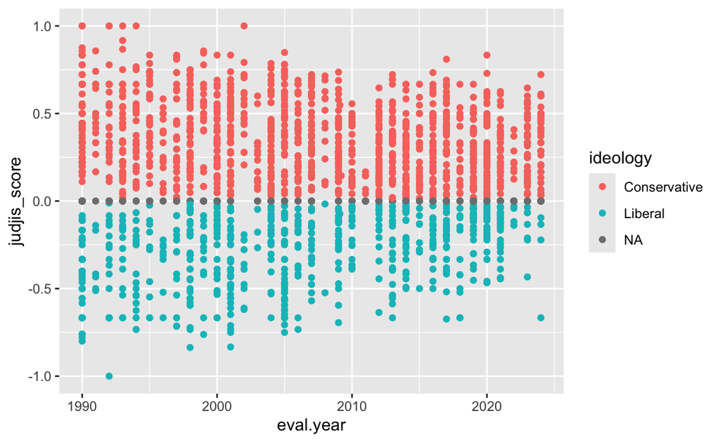

```r
judges <- judges |>
  mutate(ideology = case_when(judjis_score > 0 ~ "Conservative",
                              judjis_score < 0 ~ "Liberal"))
ggplot(data = judges, mapping = aes(x = eval.year, y = judjis_score, fill = ideology, color = ideology)) +
  geom_point()
```

Trends are difficult to pick out in this graph. Rather, let’s look at the data as differences in the average Judjis ideology scores for each party over time.

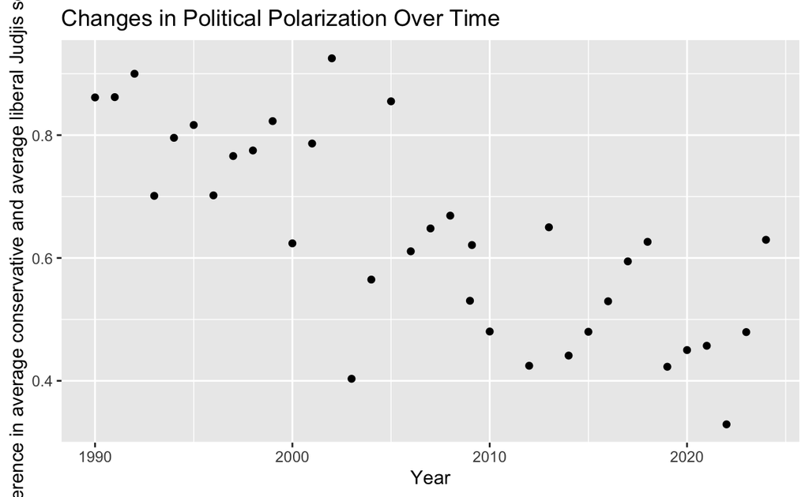

```r
judges |>
  mutate(ideology = case_when(judjis_score > 0 ~ "Conservative",
                              judjis_score < 0 ~ "Liberal")) |>
  group_by(eval.year, ideology) |>
  summarize(mean_jscore = mean(judjis_score)) |>
  drop_na() |>
  pivot_wider(
    names_from = ideology,
    values_from = mean_jscore
  ) |>
  mutate(diff_in_means = Conservative - Liberal) |>
  ggplot(aes(x = eval.year, y = diff_in_means)) +
  geom_point() +
  labs(x = "Year", y = "Difference in average conservative and average liberal Judjis scores", title = "Changes in Political Polarization Over Time")
```

This model takes the average Judjis ideology score of all conservative judges and all liberal judges, which is determined by their score being positive for conservative or negative for liberal. The averages are arranged by year and subtracted to display the difference in averaage ideologies between conservative and liberal judges. The scatter plot displays a negative relationship between the year the difference in average ideologies between judges. Thus, it would appear judges have become, on average, less polarized since the year 1990.